# Analysis of Tennis Players and Matches During 2020

## Introduction

The purpose of this project is to analyze and interpret data pulled from an open source tennis database that contains a vast amount of information about each tennis match played in the year of 2020. I will scrape the data from the website, clean it up, analyze it, and display certain sections of the data in a meaningful and readable way.

## Step 1: Importing libraries

The required libraries for this project are numpy, pandas, and matplotlib. Numpy is used because it offers a wide variety of tools and functions to manipulate the data I am using in virtually any way imaginable. Pandas is used to create dataframes with the data and it makes data manipulation very simple. Matplotlib's pyplot is used to show the data and interpret any trends I might find.

Note: the keyword 'as' just creates a shortcut for later use. Instead of calling a function like numpy.mean() I can just call np.mean() since I created the shortcut 'as' np.

```python
import numpy as np
import pandas as pd
import matplotlib.pyplot as plt
```

## Step 2: Collecting the data

Data collection is the most crucial part of any data manipulation project. It is an easy step to complete, but can be tricky to get the formatting exactly how you want. You have to be sure the file or website you want to get the data from is syntactically correct in your jupyter file.

For this project, I will be getting my data from an open source database on github. The exact link to this data set is in my code below but will also provide it below. Keep in mind it is the raw data, which is in csv format, not the webpage version.

To begin, I copied and pasted the link to the webpage and stored it as 'file'. After that I called the pandas read_csv function to create a pandas dataframe out of the csv file obtained off github.

After this was completed I called table.head() to display the first 5 rows of the data frame I just created. You can also insert an argument to .head() to display that number of rows. For example table.head(10) shows the first 10 rows of the table.

Link for data set: https://raw.githubusercontent.com/JeffSackmann/tennis_atp/master/atp_matches_2020.csv  
Pandas API: https://pandas.pydata.org/docs/reference/index.html

```python
file = 'https://raw.githubusercontent.com/JeffSackmann/tennis_atp/master/atp_matches_2020.csv'
table = pd.read_csv(file)

table.head() # Displays first 5 rows of the table by default
```

|  | tourney_id | tourney_name | surface | draw_size | tourney_level | tourney_date | match_num | winner_id | winner_seed | winner_entry | ... | l_1stIn | l_1stWon | l_2ndWon | l_SvGms | l_bpSaved | l_bpFaced | winner_rank | winner_rank_points | loser_rank | loser_rank_points |
| --- | --- | --- | --- | --- | --- | --- | --- | --- | --- | --- | --- | --- | --- | --- | --- | --- | --- | --- | --- | --- | --- |
| 0 | 2020-8888 | Atp Cup | Hard | 24 | A | 20200106 | 300 | 104925 | NaN | NaN | ... | 51.0 | 39.0 | 6.0 | 10.0 | 6.0 | 8.0 | 2.0 | 9055.0 | 1.0 | 9985.0 |
| 1 | 2020-8888 | Atp Cup | Hard | 24 | A | 20200106 | 299 | 105138 | NaN | NaN | ... | 35.0 | 21.0 | 6.0 | 9.0 | 5.0 | 10.0 | 10.0 | 2335.0 | 34.0 | 1251.0 |
| 2 | 2020-8888 | Atp Cup | Hard | 24 | A | 20200106 | 298 | 104925 | NaN | NaN | ... | 57.0 | 35.0 | 25.0 | 14.0 | 6.0 | 11.0 | 2.0 | 9055.0 | 5.0 | 5705.0 |
| 3 | 2020-8888 | Atp Cup | Hard | 24 | A | 20200106 | 297 | 105583 | NaN | NaN | ... | 54.0 | 39.0 | 14.0 | 12.0 | 0.0 | 1.0 | 34.0 | 1251.0 | 17.0 | 1840.0 |
| 4 | 2020-8888 | Atp Cup | Hard | 24 | A | 20200106 | 296 | 104745 | NaN | NaN | ... | 55.0 | 37.0 | 10.0 | 14.0 | 1.0 | 5.0 | 1.0 | 9985.0 | 18.0 | 1775.0 |

5 rows × 49 columns

## Step 3: Cleaning the data

Cleaning the data is a fancy way of saying making the data readable, and more user-friendly. As you can see above, there are way too many columns, many of which I dont care about. Also, as you can see above, the date of the tournament is in ugly format, and there are many NaN entries. NaN represents Not A Number which means the entry for that index is empty or invalid.

During the next few steps I will get into the methods and logic behind how I cleaned and tidied up the data in the dataframe. I am going to split two of the steps up to explain each one individually but if you wanted to make your program more efficient, you could do both of the next two steps inside of the same for loop.

### Step 3.1: Making the data of the match more readable

As you can see above, the data of the match is in an ugly format and for readability, and ease of use later, I will separate this one number into three separate columns containing the year, month, and day of each tennis match.

The first thing I do is create a loop that will go through each element of the table. The iterrows function accomplishes shit for me. The API for this is cited below. After I set up the loop, I grab the element at the column 'tourney_date' through the use of table.at. table.at gets the element of index[x, column] where x is being iterated. Basically I am grabbing each element in the column of 'tourney_date'. Through a little bit of debugging(I took this out later), I determined the type of the element was an integer using type(table.at[rank, 'tourney_date']). Knowing this information I could manipulate the number knowing that it was always in the form of 4 digit year, 2 digit month, 2 digit day. So through basic division and modulus I extracted which parts of the number I wanted for what. I then set the table's element at a new column created to be that value extracted. I also casted it as an int just to be sure. Normally you would think, table.at[rank, 'tourney_year'] would throw an error since 'tourney_year' isn't in the dataframe. But this syntax actually just creates a new column and inserts that value into the current row of that new column.

Iterrows API: https://pandas.pydata.org/docs/reference/api/pandas.DataFrame.iterrows.html

```python
for rank, row in table.iterrows():
    date = table.at[rank, 'tourney_date'] # getting the element

    year = int(date/10000) # parsing the integer of 'tournet_date' into its components
    month = int(date/100)%1000
    day = date%100

    table.at[rank, 'tourney_year'] = int(year) # inserting the value into the new column just created
    table.at[rank, 'tourney_month'] = int(month)
    table.at[rank, 'tourney_day'] = int(day)

table.head() # display first 5 elements
```

|  | tourney_id | tourney_name | surface | draw_size | tourney_level | tourney_date | match_num | winner_id | winner_seed | winner_entry | ... | l_SvGms | l_bpSaved | l_bpFaced | winner_rank | winner_rank_points | loser_rank | loser_rank_points | tourney_year | tourney_month | tourney_day |
| --- | --- | --- | --- | --- | --- | --- | --- | --- | --- | --- | --- | --- | --- | --- | --- | --- | --- | --- | --- | --- | --- |
| 0 | 2020-8888 | Atp Cup | Hard | 24 | A | 20200106 | 300 | 104925 | NaN | NaN | ... | 10.0 | 6.0 | 8.0 | 2.0 | 9055.0 | 1.0 | 9985.0 | 2020.0 | 1.0 | 6.0 |
| 1 | 2020-8888 | Atp Cup | Hard | 24 | A | 20200106 | 299 | 105138 | NaN | NaN | ... | 9.0 | 5.0 | 10.0 | 10.0 | 2335.0 | 34.0 | 1251.0 | 2020.0 | 1.0 | 6.0 |
| 2 | 2020-8888 | Atp Cup | Hard | 24 | A | 20200106 | 298 | 104925 | NaN | NaN | ... | 14.0 | 6.0 | 11.0 | 2.0 | 9055.0 | 5.0 | 5705.0 | 2020.0 | 1.0 | 6.0 |
| 3 | 2020-8888 | Atp Cup | Hard | 24 | A | 20200106 | 297 | 105583 | NaN | NaN | ... | 12.0 | 0.0 | 1.0 | 34.0 | 1251.0 | 17.0 | 1840.0 | 2020.0 | 1.0 | 6.0 |
| 4 | 2020-8888 | Atp Cup | Hard | 24 | A | 20200106 | 296 | 104745 | NaN | NaN | ... | 14.0 | 1.0 | 5.0 | 1.0 | 9985.0 | 18.0 | 1775.0 | 2020.0 | 1.0 | 6.0 |

5 rows × 52 columns

### Step 3.2: Cleaning up the ages

This step is for later use as you will see. The ages from the current table are floats. We don't really care about that. I just want to know how old they are in years, not their exact age in days. The following code replicates the same process as above by iterating through the table and grabbing each element from the column 'winner_age' and 'loser_age'. Then I just cast them as integers and place them right back in the same spot. I had to manually show you the column of ages due to the data being very untidy. There are too many columns to show on the screen so jupyter adds ... and cuts off some columns and the ages happen to be some of them.

```python
print(table[['winner_age', 'loser_age']])
```

```
      winner_age  loser_age
0      32.626968  33.593429
1      31.728953  29.519507
2      32.626968  23.901437
3      29.519507  23.627652
4      33.593429  20.884326
...          ...        ...
1457   30.409309  27.843943
1458   21.379877  32.755647
1459   22.976044  23.143053
1460   23.649555  21.503080
1461   22.316222  26.696783

[1462 rows x 2 columns]
```

```python
for rank, row in table.iterrows():
    w_age = int(table.at[rank, 'winner_age']) #grabs the age and casts it as an int
    l_age = int(table.at[rank, 'loser_age'])

    table.at[rank, 'winner_age'] = w_age # restores the newly casted variable back in the same spot
    table.at[rank, 'loser_age'] = l_age

print(table[['winner_age', 'loser_age']])
```

```
      winner_age  loser_age
0           32.0       33.0
1           31.0       29.0
2           32.0       23.0
3           29.0       23.0
4           33.0       20.0
...          ...        ...
1457        30.0       27.0
1458        21.0       32.0
1459        22.0       23.0
1460        23.0       21.0
1461        22.0       26.0

[1462 rows x 2 columns]
```

### Step 3.3: Dropping and renaming columns

This is my final step in tidying up the data. First I start by getting rid of any unwanted columns. This can be done using table.drop() but in this case, there were way fewer columns to keep than drop. So all I did was keep the columns I wanted through the following code.

Next I renamed certain columns to make the names shorter so they would all fit on the screen. This step is purely optional, I just wanted the data to be very easy to read. I did this through the use of the .rename function from pandas.

```python
# Making a new table called table that only contains the following columns from the original table
table = table[['tourney_name', 'surface', 'winner_name', 'winner_hand', 'winner_age',
               'loser_name', 'loser_hand', 'loser_age', 'score', 'minutes', 'tourney_year',
               'tourney_month', 'tourney_day']]

#renaming the columns to fit on the screen
table.rename(columns={'winner_name':'w_name', 'winner_hand':'w_hand', 'winner_age':'w_age',
                        'loser_name':'l_name', 'loser_hand':'l_hand', 'loser_age':'l_age',
                        'tourney_name':'tn_name', 'tourney_year':'tn_year', 'tourney_month':'tn_month',
                         'tourney_day':'tn_day'}, inplace=True)
table.head()
```

|  | tn_name | surface | w_name | w_hand | w_age | l_name | l_hand | l_age | score | minutes | tn_year | tn_month | tn_day |
| --- | --- | --- | --- | --- | --- | --- | --- | --- | --- | --- | --- | --- | --- |
| 0 | Atp Cup | Hard | Novak Djokovic | R | 32.0 | Rafael Nadal | L | 33.0 | 6-2 7-6(4) | 115.0 | 2020.0 | 1.0 | 6.0 |
| 1 | Atp Cup | Hard | Roberto Bautista Agut | R | 31.0 | Dusan Lajovic | R | 29.0 | 7-5 6-1 | 97.0 | 2020.0 | 1.0 | 6.0 |
| 2 | Atp Cup | Hard | Novak Djokovic | R | 32.0 | Daniil Medvedev | R | 23.0 | 6-1 5-7 6-4 | 167.0 | 2020.0 | 1.0 | 6.0 |
| 3 | Atp Cup | Hard | Dusan Lajovic | R | 29.0 | Karen Khachanov | R | 23.0 | 7-5 7-6(1) | 108.0 | 2020.0 | 1.0 | 6.0 |
| 4 | Atp Cup | Hard | Rafael Nadal | L | 33.0 | Alex De Minaur | R | 20.0 | 4-6 7-5 6-1 | 133.0 | 2020.0 | 1.0 | 6.0 |

## Step 4: Analysis

This is the part of the project where I will dive into the data we have obtained and start to dissect it. Doing this will help me form conclusions and draw inferences from all of this data.

To begin with, I will show you a very simple graph that is easy to create. This will help you build the skills to go in depth with the data and it will also give a visual of what the data even looks like.

### Step 4.1: Top 10 most winning players in 2020

The first thing I will do is show a bar graph of the top 10 highest winning players in 2020. I achieve this goal through the use of a python dictionary. If you haven't used dictionaries before, they are basically like hashmaps. They store a key, which in this case will be the player's name, and a value, in this case it is the number of matches won. The API for dictionaries is cited below if you want to go into more depth with them.

To start, first I created an empty dictionary. Then I cycled through the table in a similar fashion as before and grabbed the match winner's name. Then all I did was check to see if the player's name was in the dictionary using the python 'in' function. If the player was already stored, I incremented the value associated with the player by one. AKA: increased the number of games that player won. But on the other hand, if the player was not already in the dictionary, I added him to it and set the number of games won to one because this is the first occurence of them.

Once all these keys and values were in my dictionary, I sorted it by the number of games won. To do this I used a lambda expression. Lambda expressions are fast and efficient ways to sort lists, or apply a function on them. For more explanation on lambda expressions is a link below. Note that these expressions sort in ascending order. by default so I had to put the reversed keyword in to make it in descending order.

The next step was to obtain these values as a list to graph. I simply called dict.keys() and dict.values() to get these each as a list. These keys and their corresponding values have the same index in these two lists. So now that I have all of this data, I only wanted the first ten. To do this I used special syntax to only keep the first ten elements of these two lists.

Finally, we have to graph this data. All I did was created a figure, and then plotted it via bar graph with the x values being the players names, and the y values being the total number of games they won. I won't go into detail about changing the graphs appearance since everything is surface level. The API for all of the code used is cited below.

Python Dictionary API: https://docs.python.org/3/c-api/dict.html Lambda expression help: https://realpython.com/python-lambda/ plt fig API: https://matplotlib.org/3.3.4/api/_as_gen/matplotlib.figure.Figure.html

```
<BarContainer object of 10 artists>
```

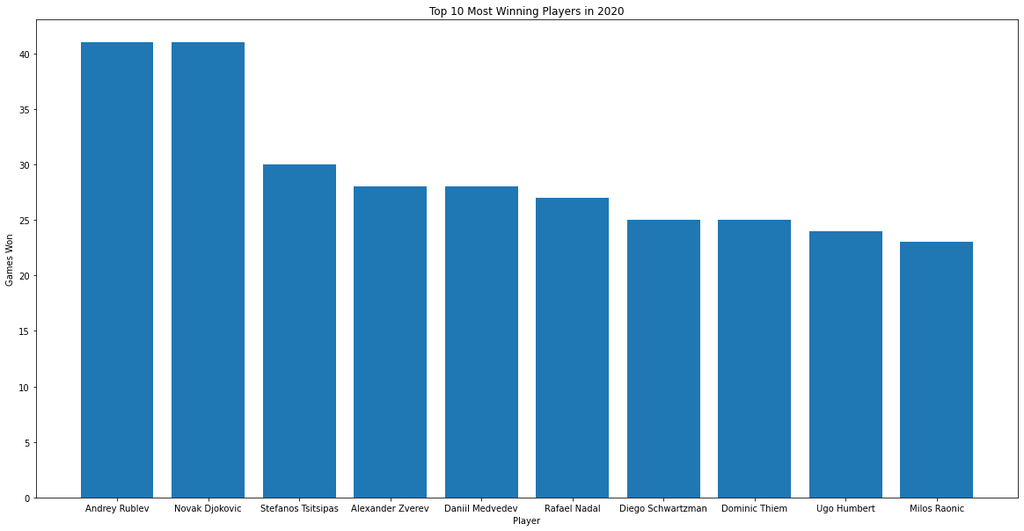

```python
top_dict = {} # creating empty dictionary

# getting all the players total games won
for rank, row in table.iterrows():
    k = table.at[rank, 'w_name']
    if k in top_dict:
        top_dict[k] = top_dict[k] + 1
    else:
        top_dict[k] = 1

# sorting dictionary by games won
top_dict = dict(reversed(sorted(top_dict.items(), key = lambda item: item[1])))

# getting keys and values to plot
names = list(top_dict.keys())
games_won = list(top_dict.values())

# getting top ten in these lists
names = names[:10]
games_won = games_won[:10]

# formatting bar graph
fig = plt.figure()
fig.set_figwidth(20)
fig.set_figheight(10)
plt.title('Top 10 Most Winning Players in 2020')
plt.xlabel('Player')
plt.ylabel('Games Won')
plt.bar(names, games_won) # plotting
```

### Step 4.2 What is the peak age for a tennis player?

Now that we are familiar with what we are doing, let's start to draw conclusions from this data. I will next find the peak age for a tennis player.

This process is identical to the graph we did above except now we are getting the age the player was when the match was won, and the total number of games won at that age.

Like before, we create an empty dictionary, populate it with the data we are looking for, sort it, and graph the results.

```
<BarContainer object of 25 artists>
```

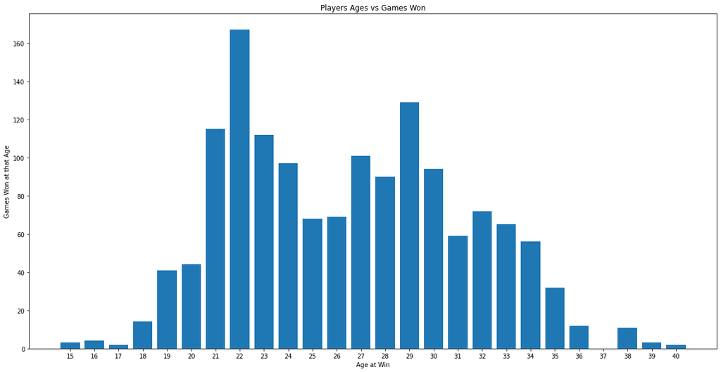

```python
age_dict = {} # initializing dictionary

# populating dictionary
for rank, row in table.iterrows():
    k = table.at[rank, 'w_age']
    if k in age_dict:
        age_dict[k] = age_dict[k] + 1
    else:
        age_dict[k] = 1

# sorting dictionary by ages
age_dict = dict((sorted(age_dict.items(), key = lambda item: item[0])))

#getting list of ages and games won at that age
ages = list(age_dict.keys())
games_won_at_age = list(age_dict.values())

# formatting bar graph
fig = plt.figure()
fig.set_figwidth(20)
fig.set_figheight(10)
plt.title('Players Ages vs Games Won')
plt.xlabel('Age at Win')
plt.ylabel('Games Won at that Age')
plt.xticks(np.arange(min(ages), max(ages)+1, 1.0))
plt.bar(ages, games_won_at_age) #graphing
```

We can now interpret this data. As shown above, it seems that there are two spikes in the top ages for playing tennis. The build up to the age of 22 is probably due to the lack of experience the younger tennis players have. Once these players turn 22, their physical capabilities and their experience is at an all time high. Between the ages of 22 and 29 the data kind of varies and we cannot draw any solid conclusions from that. But after tennis players turn 29 it appears that their total wins take a decline. This is probably due to these player's physical capabilities not being able to hold up against these younger players.

### Step 4.3 On which surfaces do tennis matches last the longest?

This information could be useful in knowing which matches are going to be more physically exhausting for players. The total time on a match can have a drastic impact on the outcome of the match.

To do this I simply made three different numpy arrays to store the length of each match in 2020 on that specific court. I then populated these arrays with the time of the match by iterating through the table and storing the time of the game on that court in the corresponding array.

Next, after these arrays were filled with the times of each match, I took the mean of the array using np.mean(). This just returns the mean of all the elements in that array.

Finally I have to plot this data. So to do that I created two new arrays of x values and y values. The x values were simply the type of court and the y values were the average length of the match played on that court. Then I plotted them using pyplot to visualize the data.

```
<BarContainer object of 3 artists>
```

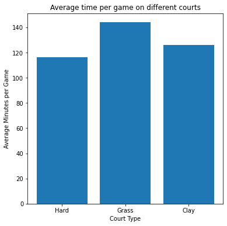

```python
hard = np.array([]) # initialized arrays
grass = np.array([])
clay = np.array([])

# populated arrays with length of the match
for rank, row in table.iterrows():
    if not np.isnan(table.at[rank, 'minutes']):
        if table.at[rank, 'surface'] == 'Hard':
            hard = np.append(hard, table.at[rank, 'minutes'])
        elif table.at[rank, 'surface'] == 'Grass':
            grass = np.append(grass, table.at[rank, 'minutes'])
        elif table.at[rank, 'surface'] == 'Clay':
            clay = np.append(clay,  table.at[rank, 'minutes'])


# found the mean of each array
mean_hard = np.mean(hard)
mean_grass = np.mean(grass)
mean_clay = np.mean(clay)

# stored these values into arrays to be graphed
x = ['Hard', 'Grass', 'Clay']
y = [mean_hard, mean_grass, mean_clay]

# formatting bar graph
fig = plt.figure()
fig.set_figwidth(6)
fig.set_figheight(6)
plt.title('Average time per game on different courts')
plt.xlabel('Court Type')
plt.ylabel('Average Minutes per Game')
plt.bar(x, y) # graphed it
```

Now we can see that grass courts have the longest matches on average. They are longer on average by around 20 minutes, around 15% longer! This is a massive difference due to just the surface these players are playing on. Knowing this, players with less stamina would be less likely to win on grass courts than players with high stamina.

### Step 4.4: Age of winner vs game length

For the final analysis I will do, I will look at how the players age and total game time are correlated. I expect there to be a dropoff of games won by older players in games that take a while due to their lack of physical capabilities.

To do this there are two parts: gather the data, and create a model. Gathering the data is the same as before and the output is shown below.

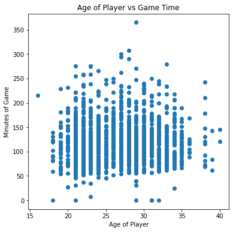

```python
age = np.array([])
game_time = np.array([])

for rank, row in table.iterrows():
    if not np.isnan(table.at[rank, 'minutes']):
        age = np.append(age, table.at[rank, 'w_age'])
        game_time = np.append(game_time, table.at[rank, 'minutes'])



# formatting scatter plot
fig = plt.figure()
fig.set_figwidth(6)
fig.set_figheight(6)
plt.title('Age of Player vs Game Time')
plt.xlabel('Age of Player')
plt.ylabel('Minutes of Game')
plt.scatter(age, game_time)
plt.show() # plotting
```

Now once we have all the data it is time to fit a line of best fit. To do this I used numpy's polyfit and poly1d function to obtain a quadratic line of best fit. Some links for more description on them are below.

Poly1d help: https://numpy.org/doc/stable/reference/generated/numpy.poly1d.html  
Polyfit help: https://numpy.org/doc/stable/reference/generated/numpy.polyfit.html

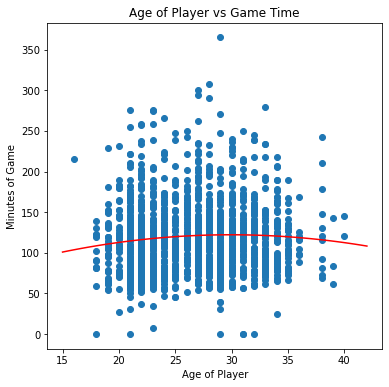

```python
model = np.poly1d(np.polyfit(age, game_time, 2)) # using numpy's library to fit a model for the data
line = np.linspace(15, 42, 50) # formatting the line

# formatting scatter plot
fig = plt.figure()
fig.set_figwidth(6)
fig.set_figheight(6)
plt.title('Age of Player vs Game Time')
plt.xlabel('Age of Player')
plt.ylabel('Minutes of Game')
plt.scatter(age, game_time) # plotting the data
plt.plot(line, model(line), color = 'red') # plotting the line of best fit previously found
plt.show()
```

After this model was fitted to the data and plotted we can see that there is a downward trend after the age of around 30. Older players do not have the stamina and physical capabilities to keep up with that of a younger player. You can also take into account the findings from earlier and draw a conclusion. Older players are less likely to win matches against younger players on grass courts.

## Conclusion

Throughout the process of this project I have found many interesting things about tennis players, things that I would not have known just by looking at this raw data. Cleaning up data is vital in this process and without it the data would nearly be unreadable. Graphing data is the best way to interpret and draw conclusions from data and fitting a linear regression model aids this task even more.